## **Predicting Breast Cancer Using Machine Learning Algorithms**

#### Jasmine Pham

July 1, 2020

[LinkedIn](https://www.linkedin.com/in/jasmine-pham)  
Email  
[Website](https://jasminepham06.wixsite.com/home)

#### **Table of Contents**

- Introduction
  - Problem Identification
  - Objective
- Data Exploration
- Classification Models in Machine Learning
  - Logistic Regression
  - Decision Tree
  - Random Forest
  - Gradient Boosting Machine
- Model Selection and Evaluation
- Conclusion

## **Introduction**

### **Problem Identification**

Breast cancer is the second most common and also the second leading cause of cancer deaths in women in the United States. According to the American Cancer Society, on average every 1 in 8 women in the United States would develop breast cancer in her lifetime and 2.6% would die from breast cancer. One of the warning symptoms of breast cancer is the development of a tumor in the breast. A tumor, however, could be either benign or malignant.

### **Objective**

This project aims to predict whether an individual has breast cancer and determine which cytological attributes are significant in identifying benign and malignant tumors. To achieve this, I performed four different classification models in machine learning, namely Logistic Regression, Decision Tree, Random Forest, and Gradient Boosting Machine, on a dataset obtained from the [UCI Machine Learning Repository](https://www.https://archive.ics.uci.edu/ml/datasets/Breast+Cancer+Wisconsin+%28Diagnostic%29). This dataset was created by Dr. William H. Wolberg from the University of Wisconsin, who took a digital scan of the fine-needle aspirates from patients with solid breast masses. Then, he used a graphical computer program called Xcyt to calculate ten cytological characteristics present in each digitized image. These features are as follows:

| # | Attribute | Domain |
| --- | --- | --- |
| 1 | Sample Code Number | ID number |
| 2 | Clump Thickness | 1 - 10 |
| 3 | Uniformity of Cell Size | 1 - 10 |
| 4 | Uniformity of Cell Shape | 1 - 10 |
| 5 | Marginal Adhesion | 1 - 10 |
| 6 | Single Epithelial Cell Size | 1 - 10 |
| 7 | Bare Nuclei | 1 - 10 |
| 8 | Bland Chromatin | 1 - 10 |
| 9 | Normal Nucleoli | 1 - 10 |
| 10 | Mitoses | 1 - 10 |

## **Data Exploration**

```r
library(tidyverse)
library(dplyr)
library(car)
library(corrplot)
library(pROC)
library(MLmetrics)
library(rpart)
library(rpart.plot)
library(randomForest)
library(varImp)
library(gbm)
library(caret)
```

```r
url <- "https://archive.ics.uci.edu/ml/machine-learning-databases/breast-cancer-wisconsin/breast-cancer-wisconsin.data"
data <- read.csv(file = url, header = FALSE,
                 col.names = c("ID","clump_thickness", "uniformity_size", "uniformity_shape", "marginal_adhesion", "single_epithelial_cell_size", "bare_nuclei", "bland_chromatin", "normal_nucleoli","mitoses", "diagnosis"))

str(data)
```

```
## 'data.frame':    699 obs. of  11 variables:
##  $ ID                         : int  1000025 1002945 1015425 1016277 1017023 1017122 1018099 1018561 1033078 1033078 ...
##  $ clump_thickness            : int  5 5 3 6 4 8 1 2 2 4 ...
##  $ uniformity_size            : int  1 4 1 8 1 10 1 1 1 2 ...
##  $ uniformity_shape           : int  1 4 1 8 1 10 1 2 1 1 ...
##  $ marginal_adhesion          : int  1 5 1 1 3 8 1 1 1 1 ...
##  $ single_epithelial_cell_size: int  2 7 2 3 2 7 2 2 2 2 ...
##  $ bare_nuclei                : Factor w/ 11 levels "?","1","10","2",..: 2 3 4 6 2 3 3 2 2 2 ...
##  $ bland_chromatin            : int  3 3 3 3 3 9 3 3 1 2 ...
##  $ normal_nucleoli            : int  1 2 1 7 1 7 1 1 1 1 ...
##  $ mitoses                    : int  1 1 1 1 1 1 1 1 5 1 ...
##  $ diagnosis                  : int  2 2 2 2 2 4 2 2 2 2 ...
```

```r
sum(data$bare_nuclei == "?")
```

```
## [1] 16
```

The dataset includes cytological characteristics of fluid samples from 699 patients. The first column consists of unique identifiers that wouldn’t be helpful for our model, so we’ll first take them out.

```r
data <- select(data, -1)
```

We’ll also exclude the 16 data points that has missing values in the *bare_nuclei* column.

```r
data <- data[data$bare_nuclei != "?",] %>% mutate(bare_nuclei = as.integer(as.character((bare_nuclei))))
```

The dependent variable *diagnosis* is now denoted as 2 that stands for “benign” and 4 that stands for “malignant”. We’ll convert it into a binary variable of 0 and 1 respectively.

```r
data <- data %>% mutate(diagnosis = ifelse(diagnosis == 2, 0, 1),
                        diagnosis = as.factor(diagnosis))
summary(data)
```

```
##  clump_thickness  uniformity_size  uniformity_shape marginal_adhesion
##  Min.   : 1.000   Min.   : 1.000   Min.   : 1.000   Min.   : 1.00
##  1st Qu.: 2.000   1st Qu.: 1.000   1st Qu.: 1.000   1st Qu.: 1.00
##  Median : 4.000   Median : 1.000   Median : 1.000   Median : 1.00
##  Mean   : 4.442   Mean   : 3.151   Mean   : 3.215   Mean   : 2.83
##  3rd Qu.: 6.000   3rd Qu.: 5.000   3rd Qu.: 5.000   3rd Qu.: 4.00
##  Max.   :10.000   Max.   :10.000   Max.   :10.000   Max.   :10.00
##  single_epithelial_cell_size  bare_nuclei     bland_chromatin  normal_nucleoli
##  Min.   : 1.000              Min.   : 1.000   Min.   : 1.000   Min.   : 1.00
##  1st Qu.: 2.000              1st Qu.: 1.000   1st Qu.: 2.000   1st Qu.: 1.00
##  Median : 2.000              Median : 1.000   Median : 3.000   Median : 1.00
##  Mean   : 3.234              Mean   : 3.545   Mean   : 3.445   Mean   : 2.87
##  3rd Qu.: 4.000              3rd Qu.: 6.000   3rd Qu.: 5.000   3rd Qu.: 4.00
##  Max.   :10.000              Max.   :10.000   Max.   :10.000   Max.   :10.00
##     mitoses       diagnosis
##  Min.   : 1.000   0:444
##  1st Qu.: 1.000   1:239
##  Median : 1.000
##  Mean   : 1.603
##  3rd Qu.: 1.000
##  Max.   :10.000
```

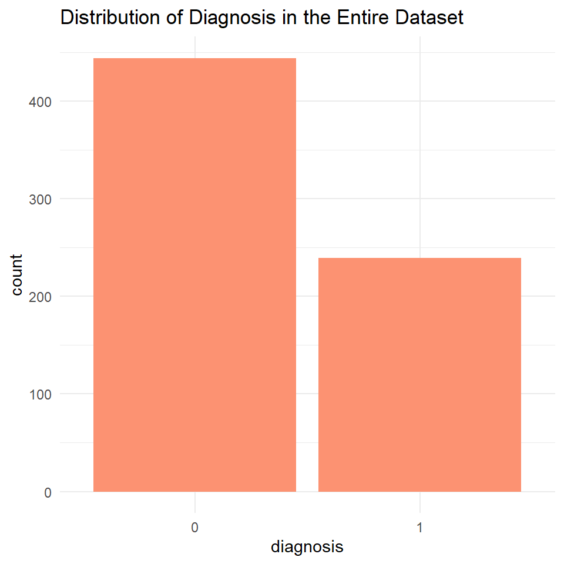

```r
ggplot(data, aes(x = diagnosis)) +
  geom_bar(fill = "#fc9272") +
  ggtitle("Distribution of Diagnosis in the Entire Dataset") +
  theme_minimal() +
  theme(legend.position = "none")
```

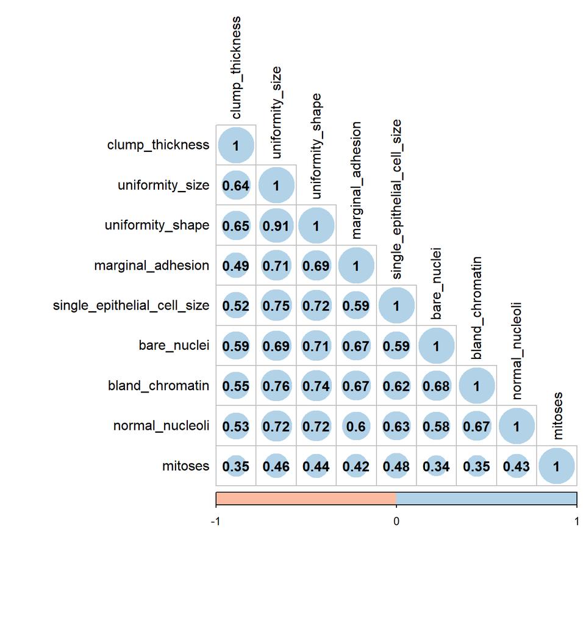

```r
correlation <- cor(data[,-10])
corrplot(correlation, type = "lower", col = c("#fcbba1", "#b2d2e8"), addCoef.col = "black", tl.col = "black")
```

Looking at the correlation between the independent variables, we can see that *uniformity_size* and *uniformity shape* are highly correlated, which might be an indication of multicollinearity.

## **Classification Models in Machine Learning**

In order to develop an accurate binary classification model, we first split our dataset randomly into a training and a test set.

```r
set.seed(3011)
train_index <- sample(nrow(data), size = round(0.75 * nrow(data)), replace = FALSE)
train <- data[train_index,]
test <- data[-train_index,]
```

### **Logistic Regression**

```r
# Develop and tune the logistic regression model on the training dataset
lm <- glm(formula = diagnosis ~ ., data = train, family = binomial())
summary(lm)
```

```
##
## Call:
## glm(formula = diagnosis ~ ., family = binomial(), data = train)
##
## Deviance Residuals:
##      Min        1Q    Median        3Q       Max
## -2.78585  -0.09901  -0.05573   0.01655   2.67351
##
## Coefficients:
##                             Estimate Std. Error z value Pr(>|z|)
## (Intercept)                 -10.9307     1.4908  -7.332 2.27e-13 ***
## clump_thickness               0.5503     0.1717   3.205  0.00135 **
## uniformity_size              -0.3486     0.2811  -1.240  0.21488
## uniformity_shape              0.4196     0.3033   1.384  0.16647
## marginal_adhesion             0.3406     0.1492   2.283  0.02240 *
## single_epithelial_cell_size   0.2727     0.2099   1.299  0.19390
## bare_nuclei                   0.3466     0.1086   3.191  0.00142 **
## bland_chromatin               0.5763     0.1978   2.913  0.00357 **
## normal_nucleoli               0.3801     0.1562   2.434  0.01494 *
## mitoses                       0.5530     0.3774   1.465  0.14283
## ---
## Signif. codes:  0 '***' 0.001 '**' 0.01 '*' 0.05 '.' 0.1 ' ' 1
##
## (Dispersion parameter for binomial family taken to be 1)
##
##     Null deviance: 648.031  on 511  degrees of freedom
## Residual deviance:  68.586  on 502  degrees of freedom
## AIC: 88.586
##
## Number of Fisher Scoring iterations: 8
```

```r
vif(lm)
```

```
##             clump_thickness             uniformity_size
##                    1.225315                    4.265839
##            uniformity_shape           marginal_adhesion
##                    4.023195                    1.196004
## single_epithelial_cell_size                 bare_nuclei
##                    1.409701                    1.148769
##             bland_chromatin             normal_nucleoli
##                    1.326350                    1.158661
##                     mitoses
##                    1.116602
```

As predicted, both *uniformity_size* and *uniformity_shape* has a significantly higher VIF than other variables because of their high correlation. However, as a rule of thumb, a VIF lower than 5 is still acceptable, and thus we don’t have to exclude these variables out of the model.

```r
lm2 <- glm(formula = diagnosis ~ ., data = train %>% select(-c(uniformity_size, single_epithelial_cell_size, mitoses)), family = binomial())
summary(lm2)
```

```
##
## Call:
## glm(formula = diagnosis ~ ., family = binomial(), data = train %>%
##     select(-c(uniformity_size, single_epithelial_cell_size, mitoses)))
##
## Deviance Residuals:
##      Min        1Q    Median        3Q       Max
## -2.58047  -0.10760  -0.05289   0.01724   2.48016
##
## Coefficients:
##                   Estimate Std. Error z value Pr(>|z|)
## (Intercept)       -10.1772     1.3467  -7.557 4.12e-14 ***
## clump_thickness     0.6471     0.1602   4.039 5.36e-05 ***
## uniformity_shape    0.2518     0.1864   1.351  0.17661
## marginal_adhesion   0.3635     0.1410   2.578  0.00993 **
## bare_nuclei         0.3534     0.1086   3.256  0.00113 **
## bland_chromatin     0.5391     0.1877   2.871  0.00409 **
## normal_nucleoli     0.3725     0.1408   2.645  0.00817 **
## ---
## Signif. codes:  0 '***' 0.001 '**' 0.01 '*' 0.05 '.' 0.1 ' ' 1
##
## (Dispersion parameter for binomial family taken to be 1)
##
##     Null deviance: 648.031  on 511  degrees of freedom
## Residual deviance:  74.553  on 505  degrees of freedom
## AIC: 88.553
##
## Number of Fisher Scoring iterations: 8
```

```r
lm3 <- glm(formula = diagnosis ~ ., data = train %>% select(-c(uniformity_size, single_epithelial_cell_size, bare_nuclei, mitoses)), family = binomial())
summary(lm3)
```

```
##
## Call:
## glm(formula = diagnosis ~ ., family = binomial(), data = train %>%
##     select(-c(uniformity_size, single_epithelial_cell_size, bare_nuclei,
##         mitoses)))
##
## Deviance Residuals:
##      Min        1Q    Median        3Q       Max
## -2.51441  -0.11798  -0.06096   0.01500   2.88791
##
## Coefficients:
##                   Estimate Std. Error z value Pr(>|z|)
## (Intercept)       -10.1932     1.2372  -8.239  < 2e-16 ***
## clump_thickness     0.6364     0.1470   4.329  1.5e-05 ***
## uniformity_shape    0.5146     0.1730   2.975 0.002934 **
## marginal_adhesion   0.4052     0.1283   3.159 0.001582 **
## bland_chromatin     0.6861     0.1765   3.888 0.000101 ***
## normal_nucleoli     0.3906     0.1394   2.802 0.005081 **
## ---
## Signif. codes:  0 '***' 0.001 '**' 0.01 '*' 0.05 '.' 0.1 ' ' 1
##
## (Dispersion parameter for binomial family taken to be 1)
##
##     Null deviance: 648.03  on 511  degrees of freedom
## Residual deviance:  86.48  on 506  degrees of freedom
## AIC: 98.48
##
## Number of Fisher Scoring iterations: 8
```

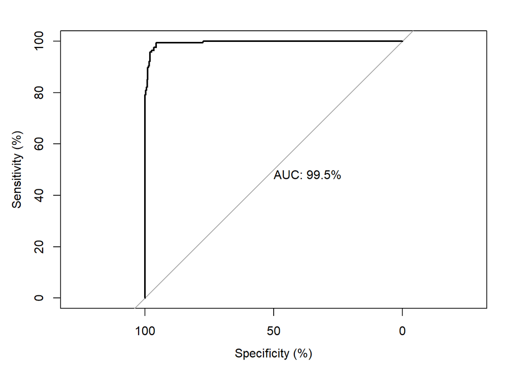

```r
pred_train_lm <- predict(lm3, train, type = 'response')
AUC_train_lm <- roc(train$diagnosis, pred_train_lm, percent = TRUE, plot = TRUE, print.auc = TRUE)
```

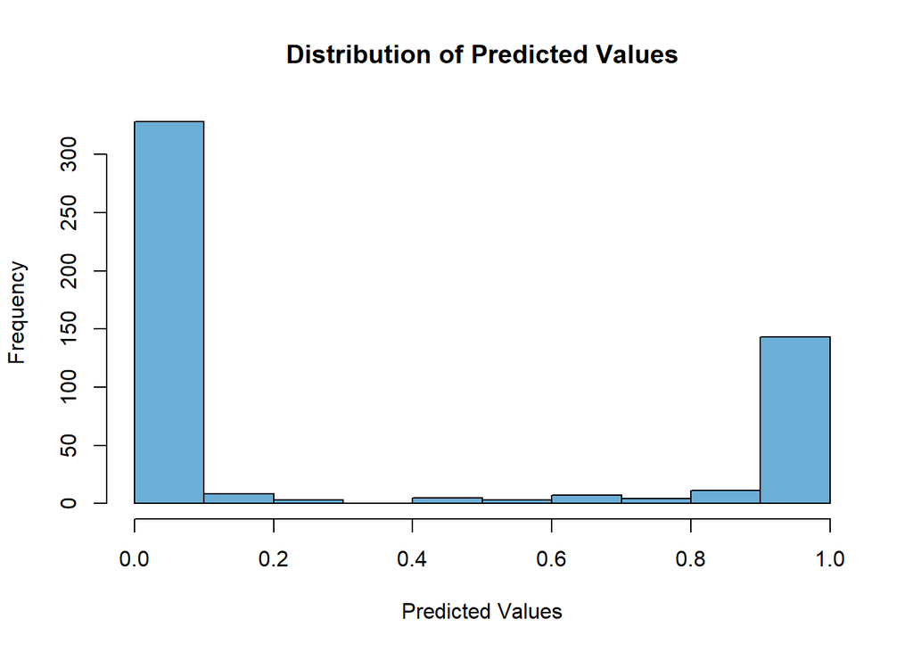

```r
hist(pred_train_lm,
     main = "Distribution of Predicted Values",
     xlab = "Predicted Values",
     col = "#6baed6",
     border = NULL)
```

The histogram is positively skewed, which is understandable because in our original dataset, we have almost twice as many benign tumors than malignant lumps. With that being said, if we use the regular threshold of 0.5 to categorize the predicted values into binary levels, we would end up with an unfitted model. Therefore, we now create a loop to find the threshold that maximizes classification performance metrics.

```r
accuracy <- 0
f1 <- 0
threshold <- 0

for(i in seq(0.1, 0.9, by = 0.01)){
  pred_cat_train <- ifelse(pred_train_lm < i, 0, 1)
  a = Accuracy(y_true = train$diagnosis, y_pred = pred_cat_train)
  b = F1_Score(y_true = train$diagnosis, y_pred = pred_cat_train)

  if(a > accuracy & b > f1){
    accuracy = a
    f1 = b
    threshold = i
  }
}
accuracy
```

```
## [1] 0.9726562
```

```r
f1
```

```
## [1] 0.9796512
```

```r
threshold
```

```
## [1] 0.48
```

Now let’s apply the final logistic regression model to our test dataset as well as calculate and display different performance measures using the optimized threshold of 0.48.

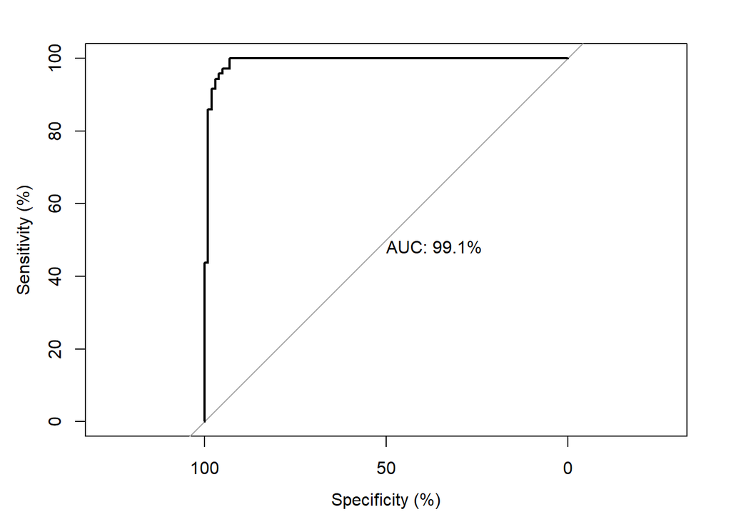

```r
pred_test_lm <- predict(lm3, test, type = 'response')

AUC_test_lm <- roc(test$diagnosis, pred_test_lm, percent = TRUE, plot = TRUE, print.auc = TRUE)
```

```r
pred_cat_test <- ifelse(pred_test_lm >= 0.48, 1, 0)
Accuracy(y_true = test$diagnosis, y_pred = pred_cat_test)
```

```
## [1] 0.9590643
```

```r
F1_Score(y_true = test$diagnosis, y_pred = pred_cat_test)
```

```
## [1] 0.964467
```

```r
ConfusionMatrix(y_true = test$diagnosis, y_pred = pred_cat_test)
```

```
##       y_pred
## y_true  0  1
##      0 95  5
##      1  2 69
```

### **Decision Tree**

We will run the decision tree model through a grid search of *minsplit* (the minimum number of observations in each split) and *maxdepth* (the maximum depth of the tree) in order to find the optimized combination of hyperparameters.

```r
AUC_train_besttree <- 0
AUC_test_besttree <- 0
AUC_tree <- data.frame(AUC_train_tree = numeric(), AUC_test_tree = numeric())

set.seed(3011)
tree_parameters <- data.frame(minsplit_para = floor(runif(8, 10, 60)),
                              maxdepth_para = floor(runif(8, 10, 30)))

for(para_comb in 1:nrow(tree_parameters)){
  decision_tree <- rpart(diagnosis ~ .,  data = train,
                      control = rpart.control(minsplit = tree_parameters[para_comb, "minsplit_para"],
                                              maxdepth = tree_parameters[para_comb, "maxdepth_para"]))

  pred_train_tree <- as.data.frame(predict(decision_tree, train, type='prob'))
  AUC_train_tree <- roc(train$diagnosis, pred_train_tree$`1`, percent = TRUE, plot = TRUE)

  pred_test_tree <- as.data.frame(predict(decision_tree, test, type='prob'))
  AUC_test_tree <- roc(test$diagnosis, pred_test_tree$`1`, percent = TRUE, plot = TRUE)

  AUC_tree[para_comb, ] <- c(round(AUC_train_tree$auc, 2), round(AUC_test_tree$auc, 2))
  AUC_train_besttree = ifelse(AUC_train_besttree > AUC_train_tree$auc, AUC_train_besttree, AUC_train_tree$auc)
  AUC_test_besttree = ifelse(AUC_test_besttree > AUC_test_tree$auc, AUC_test_besttree, AUC_test_tree$auc)
}
```

| minsplit_para | maxdepth_para | AUC_train_tree | AUC_test_tree |
| --- | --- | --- | --- |
| 22 | 12 | 95.52 | 93.97 |
| 14 | 24 | 96.65 | 95.87 |
| 10 | 18 | 97.14 | 96.44 |
| 15 | 14 | 96.65 | 95.87 |
| 29 | 15 | 95.52 | 93.97 |
| 42 | 25 | 95.52 | 93.97 |
| 59 | 28 | 96.51 | 94.51 |
| 11 | 10 | 97.57 | 95.04 |

According to our grid search, the best decision tree has a minsplit of 11 and maxdepth of 10.

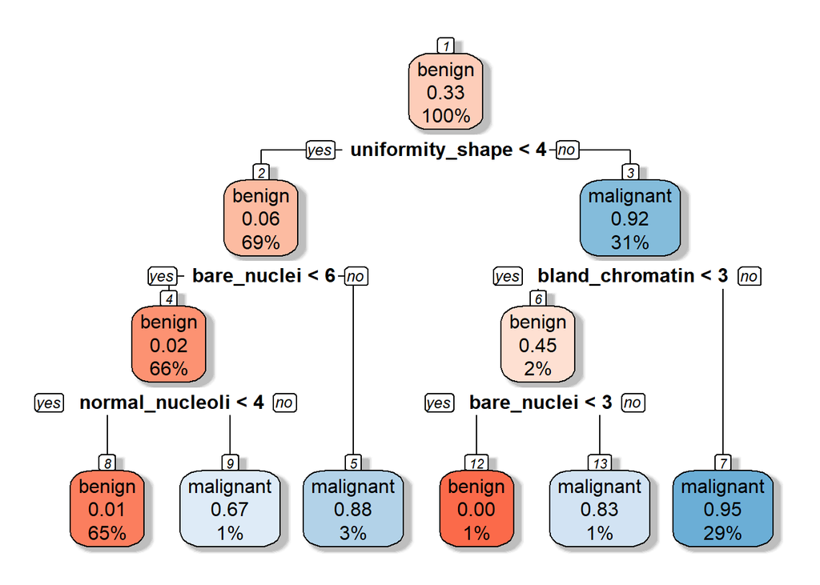

```r
best_decision_tree <- rpart(diagnosis ~., data = train,
                            control = rpart.control(minsplit = 11,
                                                    maxdepth = 10))
rpart.plot(x = best_decision_tree, box.palette="RdBu", shadow.col="gray", nn=TRUE, yesno = 2)
```

### **Random Forest**

Similarly, we will run the random forest model through a grid search to find the optimized combination of hyperparameters. The hyperparameters used are *nodesize* (the minimum number of observations in the terminal nodes), *sampsize* (the sample size of each tree), *mtry* (the number of variables to be considered for each tree), and *ntree* (the number of decision trees that constitute the forest).

```r
AUC_train_bestrf <- 0
AUC_test_bestrf <- 0
AUC_rf <- data.frame(AUC_train_rf = numeric(), AUC_test_rf = numeric())

set.seed(160)
rf_parameters <- data.frame(nodesize = round(runif(10,5,20)),
                            sampsize= round(runif(10,1,400)),
                            mtry = round(runif(10,1,10)),
                            ntree = round(runif(10,1,400)))

for(paracomb_rf in 1:nrow(rf_parameters)){
  random_forest <- randomForest(diagnosis ~ ., data = train,
                                nodesize = rf_parameters[paracomb_rf, "nodesize"],
                                sampsize = rf_parameters[paracomb_rf, "sampsize"],
                                mtry = rf_parameters[paracomb_rf, "mtry"],
                                ntree = rf_parameters[paracomb_rf, "ntree"])

  pred_train_rf <- as.data.frame(predict(random_forest, train, type='prob'))
  AUC_train_rf <- roc(train$diagnosis, pred_train_rf$`1`, percent = TRUE, plot = TRUE)

  pred_test_rf <- as.data.frame(predict(random_forest, test, type='prob'))
  AUC_test_rf <- roc(test$diagnosis, pred_test_rf$`1`, percent = TRUE, plot = TRUE)

  AUC_rf[paracomb_rf, ] <- c(round(AUC_train_rf$au, 2), round(AUC_test_rf$auc, 2))
  AUC_train_bestrf = ifelse(AUC_train_bestrf > AUC_train_rf$auc, AUC_train_bestrf, AUC_train_rf$auc)
  AUC_test_bestrf = ifelse(AUC_test_bestrf > AUC_test_rf$auc, AUC_test_bestrf, AUC_test_rf$auc)
}
```

| nodesize | sampsize | mtry | ntree | AUC_train_rf | AUC_test_rf |
| --- | --- | --- | --- | --- | --- |
| 16 | 398 | 7 | 205 | 99.66 | 98.66 |
| 15 | 366 | 6 | 358 | 99.66 | 98.43 |
| 8 | 32 | 9 | 339 | 99.36 | 98.75 |
| 13 | 305 | 4 | 8 | 99.05 | 97.52 |
| 17 | 50 | 5 | 188 | 99.48 | 98.81 |
| 9 | 293 | 7 | 189 | 99.80 | 98.77 |
| 15 | 37 | 9 | 172 | 99.42 | 99.09 |
| 19 | 303 | 3 | 222 | 99.56 | 98.58 |
| 9 | 329 | 7 | 210 | 99.83 | 98.87 |
| 11 | 196 | 6 | 118 | 99.60 | 98.68 |

According to the grid search, the best random forest model would have a nodesize of 9, sampsize of 329, mtry of 7, and ntree of 210.

```r
best_random_forest <- randomForest(diagnosis ~ ., data = train,
                                   nodesize = 9,
                                   sampsize = 329,
                                   mtry = 7,
                                   ntree = 210)
best_random_forest
```

```
##
## Call:
##  randomForest(formula = diagnosis ~ ., data = train, nodesize = 9,      sampsize = 329, mtry = 7, ntree = 210)
##                Type of random forest: classification
##                      Number of trees: 210
## No. of variables tried at each split: 7
##
##         OOB estimate of  error rate: 3.12%
## Confusion matrix:
##     0   1 class.error
## 0 334  10  0.02906977
## 1   6 162  0.03571429
```

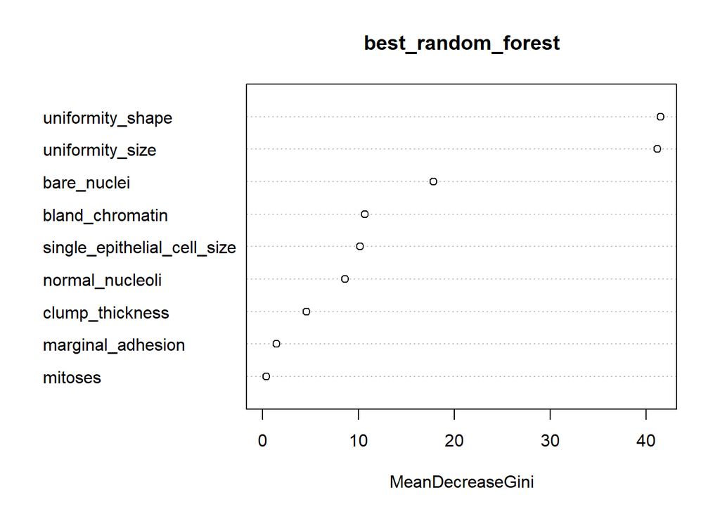

```r
# Identify the most significant independent variables
varImpPlot(best_random_forest)
```

### **Gradient Boosting Machine**

Lastly, we will run the gradient boosting model through a grid search to find the optimized combination of hyperparameters. The hyperparameters used are *n.trees* (the number of decision trees), *shrinkage* (learning rate), *interaction.depth* (the depth of each tree) *bag.fraction* (the sample size of each tree as a fraction of the dataset), and *n.minobsinnode* (the minimum number of observations in the terminal nodes).

```r
AUC_train_bestgb <- 0
AUC_test_bestgb <-0
AUC_gb <- data.frame(AUC_train_gb = numeric(), AUC_test_gb = numeric())

set.seed(3011)
gb_parameters <- data.frame(sample_size = round(runif(10,0.5,1), 2),
                           min_size= round(runif(10,5,20)),
                           num_tree = round(runif(10,20,200)),
                           shrink = round(runif(10,0.1,0.5), 2))

for(paracomb_gb in 1:nrow(gb_parameters)){
  gradient_boosting <- gbm(diagnosis ~ ., data = train,
                           distribution = "bernoulli",
                           n.trees = gb_parameters[paracomb_gb,'num_tree'],
                           shrinkage = gb_parameters[paracomb_gb,'shrink'],
                           interaction.depth = 3,
                           bag.fraction = gb_parameters[paracomb_gb,'sample_size'],
                           n.minobsinnode = gb_parameters[paracomb_gb,'min_size'],
                           verbose = TRUE)

  pred_train_gb <- predict(gradient_boosting, train, type = "response", n.trees = gb_parameters[paracomb_gb,'num_tree'])
  AUC_train_gb <- roc(train$diagnosis, pred_train_gb, percent = TRUE, plot = TRUE)

  pred_test_gb <- predict(gradient_boosting, test, type = "response", n.trees = gb_parameters[paracomb_gb,'num_tree'])
  AUC_test_gb <- roc(test$diagnosis, pred_test_gb, percent = TRUE, plot = TRUE)

  AUC_gb[paracomb_gb, ] <- c(round(AUC_train_gb$auc,2), round(AUC_test_gb$auc,2))
  AUC_train_bestgb = ifelse(AUC_train_bestgb > AUC_train_gb$auc, AUC_train_bestgb, AUC_train_gb$auc)
  AUC_test_bestgb = ifelse(AUC_test_bestgb > AUC_test_gb$auc, AUC_test_bestgb, AUC_test_gb$auc)

}
```

| sample_size | min_size | num_tree | shrink | AUC_train_gb | AUC_test_gb |
| --- | --- | --- | --- | --- | --- |
| 0.63 | 11 | 87 | 0.24 | 100 | 98.73 |
| 0.54 | 8 | 154 | 0.17 | 100 | 98.89 |
| 0.51 | 9 | 195 | 0.29 | 100 | 98.66 |
| 0.55 | 17 | 171 | 0.43 | 100 | 98.75 |
| 0.70 | 19 | 103 | 0.47 | 100 | 98.58 |
| 0.83 | 5 | 148 | 0.14 | 100 | 99.08 |
| 0.99 | 17 | 199 | 0.39 | 100 | 98.87 |
| 0.51 | 9 | 150 | 0.36 | 100 | 98.46 |
| 0.55 | 6 | 159 | 0.42 | 100 | 98.94 |
| 0.86 | 17 | 192 | 0.45 | 100 | 98.94 |

```r
best_gradient_boosting <- gbm(diagnosis ~ ., data = train,
                           distribution = "bernoulli",
                           n.trees = 159,
                           shrinkage = 0.42,
                           interaction.depth = 3,
                           bag.fraction = 0.55,
                           n.minobsinnode = 6,
                           verbose = TRUE)
```

### **Model Selection and Evaluation**

Now, we will evaluate all four classification models by comparing their area under the curve (AUC) when fitted into the training, test, and the entire datasets.

```r
kable(AUC_values) %>%  kable_styling(bootstrap_options = c("hover", "condensed", "responsive"), full_width = F)
```

| Model | AUC_train | AUC_test | AUC_data |
| --- | --- | --- | --- |
| Logistic Regression | 99.53 | 99.06 | 99.43 |
| Decision Tree | 97.57 | 96.44 | 96.93 |
| Random Forest | 99.83 | 99.09 | 99.51 |
| Gradient Boosting Machine | 100.00 | 99.08 | 99.75 |

All four models have a high performance, probably due to the extreme differences in cytological features between benign and malignant tumors. In this case, I’d choose the gradient boosting model for their exceptionally high and consistent performance across all datasets. Let’s take a closer look at other performance measures of this prediction model.

```r
pred_test_bestgb <- predict(best_gradient_boosting, test, type = "response", n.trees = 159)
pred_cat_test_gb <- as.factor(ifelse(pred_test_bestgb < 0.5, 0, 1))
confusionMatrix(pred_cat_test_gb, test$diagnosis)
```

```
## Confusion Matrix and Statistics
##
##           Reference
## Prediction  0  1
##          0 94  1
##          1  6 70
##
##                Accuracy : 0.9591
##                  95% CI : (0.9175, 0.9834)
##     No Information Rate : 0.5848
##     P-Value [Acc > NIR] : <2e-16
##
##                   Kappa : 0.9166
##
##  Mcnemar's Test P-Value : 0.1306
##
##             Sensitivity : 0.9400
##             Specificity : 0.9859
##          Pos Pred Value : 0.9895
##          Neg Pred Value : 0.9211
##              Prevalence : 0.5848
##          Detection Rate : 0.5497
##    Detection Prevalence : 0.5556
##       Balanced Accuracy : 0.9630
##
##        'Positive' Class : 0
##
```

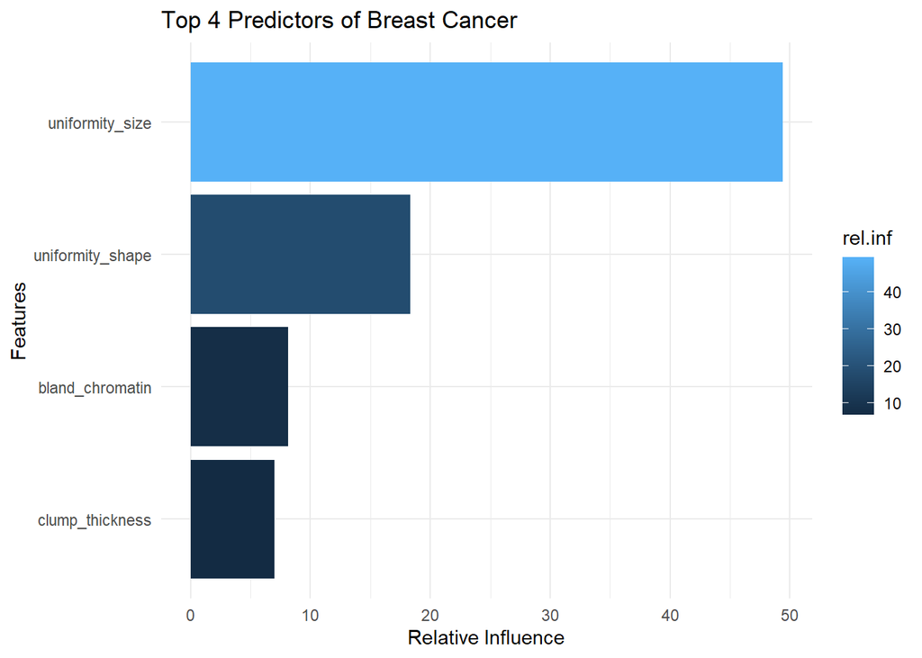

```r
rel_inf_gb <- as.data.frame(summary.gbm(best_gradient_boosting, plotit = FALSE))
rel_inf_gb %>%
  arrange(desc(rel.inf)) %>%
  top_n(4) %>%
  ggplot(aes(x = reorder(var, rel.inf),
             y = rel.inf,
             fill = rel.inf)) +
  geom_col() +
  coord_flip() +
  xlab('Features') +
  ylab('Relative Influence') +
  ggtitle("Top 4 Predictors of Breast Cancer") +
  theme_minimal()
```

Based on this gradient boosting model, the top most influential variables are *uniformity_size*, *uniformity_shape*, *bland_chromatin*, and *clump_thickness*.